# Biostat 203B Homework 2

Due Feb 6 @ 11:59PM

Lilly Huang

```r
knitr::opts_chunk$set(echo = TRUE, cache = TRUE, cache.lazy = FALSE)
library(tidyverse)
library(data.table)
library(lubridate)
library(vtable)
library(qwraps2)
```

```r
os <- sessionInfo()$running
if (str_detect(os, "Linux")) {
  mimic_path <- "/mnt/mimiciv/1.0"
} else if (str_detect(os, "macOS")) {
  mimic_path <- "/Users/huazhou/Documents/Box Sync/MIMIC/mimic-iv-1.0"
}
```

In this exercise, we use tidyverse (ggpot2, dplyr, etc) to explore the [MIMIC-IV](https://mimic.mit.edu/docs/iv/) data introduced in [homework 1](https://ucla-biostat-203b.github.io/2022winter/hw/hw1/hw1.html) and to build a cohort of ICU stays.

```r
# tree -s -L 2 /Users/huazhou/Documents/Box\ Sync/MIMIC/mimic-iv-1.0
system(str_c("tree -s -L 2 ", shQuote(mimic_path)), intern = TRUE)
```

```
##  [1] "/mnt/mimiciv/1.0"
##  [2] "├── [       4096]  core"
##  [3] "│   ├── [   17208966]  admissions.csv.gz"
##  [4] "│   ├── [        606]  index.html"
##  [5] "│   ├── [    2955582]  patients.csv.gz"
##  [6] "│   └── [   53014503]  transfers.csv.gz"
##  [7] "├── [       4096]  hosp"
##  [8] "│   ├── [     430049]  d_hcpcs.csv.gz"
##  [9] "│   ├── [   29531152]  diagnoses_icd.csv.gz"
## [10] "│   ├── [     863239]  d_icd_diagnoses.csv.gz"
## [11] "│   ├── [     579998]  d_icd_procedures.csv.gz"
## [12] "│   ├── [      14898]  d_labitems.csv.gz"
## [13] "│   ├── [   11684062]  drgcodes.csv.gz"
## [14] "│   ├── [  515763427]  emar.csv.gz"
## [15] "│   ├── [  476252563]  emar_detail.csv.gz"
```

[output cut: 26 more lines]

## Q1. `read.csv` (base R) vs `read_csv` (tidyverse) vs `fread` (data.table)

There are quite a few utilities in R for reading plain text data files. Let us test the speed of reading a moderate sized compressed csv file, `admissions.csv.gz`, by three programs: `read.csv` in base R, `read_csv` in tidyverse, and `fread` in the popular data.table package.

Which function is fastest? Is there difference in the (default) parsed data types? (Hint: R function `system.time` measures run times.)

For later questions, we stick to the tidyverse. **Solution**

```r
admissiondt = "/mnt/mimiciv/1.0/core/admissions.csv.gz"
```

```r
system.time(read.csv(admissiondt))
```

```
##    user  system elapsed
##  41.916   1.513  43.443
```

```r
system.time(read_csv(admissiondt))
```

```
##    user  system elapsed
##   3.368   0.424   2.318
```

```r
system.time(fread(admissiondt))
```

```
##    user  system elapsed
##   1.630   0.110   0.933
```

Fread in the popular data.table package is the fastest.There is a difference in how they read the data. ‘Fread’ read the data by mapping.However, ‘read.csv’ read the data line by line.

## Q2. ICU stays

`icustays.csv.gz` (https://mimic.mit.edu/docs/iv/modules/icu/icustays/) contains data about Intensive Care Units (ICU) stays. The first 10 lines are

```r
system(
  str_c(
    "zcat < ",
    shQuote(str_c(mimic_path, "/icu/icustays.csv.gz")),
    " | head"
    ),
  intern = TRUE
)
```

```
##  [1] "subject_id,hadm_id,stay_id,first_careunit,last_careunit,intime,outtime,los"
##  [2] "17867402,24528534,31793211,Trauma SICU (TSICU),Trauma SICU (TSICU),2154-03-03 04:11:00,2154-03-04 18:16:56,1.5874537037037035"
##  [3] "14435996,28960964,31983544,Trauma SICU (TSICU),Trauma SICU (TSICU),2150-06-19 17:57:00,2150-06-22 18:33:54,3.025625"
##  [4] "17609946,27385897,33183475,Trauma SICU (TSICU),Trauma SICU (TSICU),2138-02-05 18:54:00,2138-02-15 12:42:05,9.741724537037038"
##  [5] "18966770,23483021,34131444,Trauma SICU (TSICU),Trauma SICU (TSICU),2123-10-25 10:35:00,2123-10-25 18:59:47,0.35054398148148147"
##  [6] "12776735,20817525,34547665,Neuro Stepdown,Neuro Stepdown,2200-07-12 00:33:00,2200-07-13 16:44:40,1.6747685185185184"
##  [7] "10215159,24283593,34569476,Trauma SICU (TSICU),Trauma SICU (TSICU),2124-09-20 15:05:29,2124-09-21 22:06:58,1.2926967592592593"
##  [8] "14489052,26516390,35056286,Trauma SICU (TSICU),Trauma SICU (TSICU),2118-10-26 10:33:56,2118-10-26 20:28:10,0.4126620370370371"
##  [9] "15914763,28906020,36909804,Trauma SICU (TSICU),Trauma SICU (TSICU),2176-12-14 12:00:00,2176-12-17 11:47:01,2.9909837962962964"
## [10] "16256226,20013290,39289362,Neuro Stepdown,Neuro Stepdown,2150-12-20 16:09:08,2150-12-21 14:58:40,0.9510648148148149"
```

1. Import `icustatys.csv.gz` as a tibble `icustays_tble`.

```r
library(tibble)
```

```r
icustays_tble =
  read_csv(str_c(mimic_path, "/icu/icustays.csv.gz"))
```

2. How many unique `subject_id`? Can a `subject_id` have multiple ICU stays?

**solution:**

```r
icustays_tble %>%
  distinct(subject_id) %>%
    nrow() %>%
      str_c(., "unique subject_id")
```

```
## [1] "53150unique subject_id"
```

```r
icustays_tble %>%
  distinct(stay_id) %>%
    nrow() %>%
      str_c(., "unique stay_id")
```

```
## [1] "76540unique stay_id"
```

Yes, since 76540 unique stay_id presents while only 53150 unique subject_id presents,therefor, subject_id can have multipe ICU stays.

3. For each `subject_id`, let’s only keep the first ICU stay in the tibble `icustays_tble`.

```r
icustays_tble =
  distinct(icustays_tble, subject_id, .keep_all = TRUE)
```

## Q3. `admission` data

Information of the patients admitted into hospital is available in `admissions.csv.gz`. See https://mimic.mit.edu/docs/iv/modules/core/admissions/ for details of each field in this file. The first 10 lines are

```r
system(
  str_c(
    "zcat < ",
    shQuote(str_c(mimic_path, "/core/admissions.csv.gz")),
    " | head"
    ),
  intern = TRUE
)
```

```
##  [1] "subject_id,hadm_id,admittime,dischtime,deathtime,admission_type,admission_location,discharge_location,insurance,language,marital_status,ethnicity,edregtime,edouttime,hospital_expire_flag"
##  [2] "14679932,21038362,2139-09-26 14:16:00,2139-09-28 11:30:00,,ELECTIVE,,HOME,Other,ENGLISH,SINGLE,UNKNOWN,,,0"
##  [3] "15585972,24941086,2123-10-07 23:56:00,2123-10-12 11:22:00,,ELECTIVE,,HOME,Other,ENGLISH,,WHITE,,,0"
##  [4] "11989120,21965160,2147-01-14 09:00:00,2147-01-17 14:25:00,,ELECTIVE,,HOME,Other,ENGLISH,,UNKNOWN,,,0"
##  [5] "17817079,24709883,2165-12-27 17:33:00,2165-12-31 21:18:00,,ELECTIVE,,HOME,Other,ENGLISH,,OTHER,,,0"
##  [6] "15078341,23272159,2122-08-28 08:48:00,2122-08-30 12:32:00,,ELECTIVE,,HOME,Other,ENGLISH,,BLACK/AFRICAN AMERICAN,,,0"
##  [7] "19124609,20517215,2169-03-14 12:44:00,2169-03-20 19:15:00,,ELECTIVE,,HOME,Other,ENGLISH,,UNKNOWN,,,0"
##  [8] "17301855,29732723,2140-06-06 14:23:00,2140-06-08 14:25:00,,ELECTIVE,,HOME,Other,ENGLISH,,WHITE,,,0"
##  [9] "17991012,24298836,2181-07-10 20:28:00,2181-07-12 15:49:00,,ELECTIVE,,HOME,Other,ENGLISH,,WHITE,,,0"
## [10] "16865435,23216961,2185-07-19 02:12:00,2185-07-21 11:50:00,,ELECTIVE,,HOME,Other,ENGLISH,,WHITE,,,0"
```

1. Import `admissions.csv.gz` as a tibble `admissions_tble`.

```r
admission_tble =
  read_csv(str_c(mimic_path, "/core/admissions.csv.gz"))
```

2. Let’s only keep the admissions that have a match in `icustays_tble` according to `subject_id` and `hadmi_id`.

```r
admission_tble =
  semi_join(admission_tble, icustays_tble, by = c("subject_id", "hadm_id"))
```

3. Summarize the following variables by graphics.
- admission year

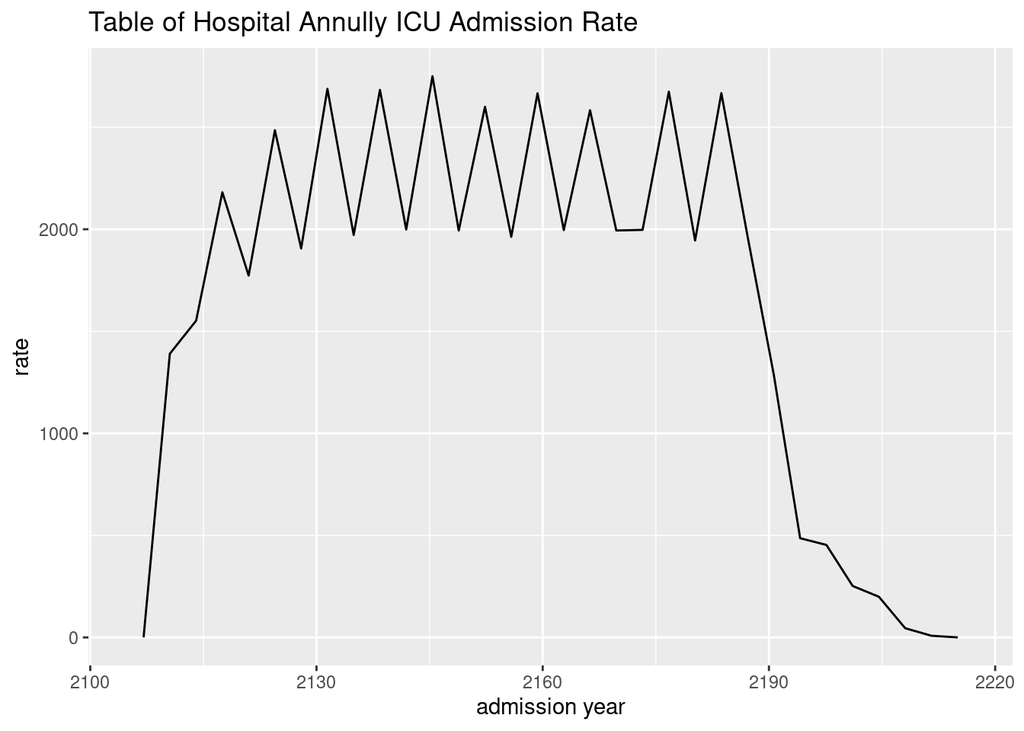

```r
admyeartb=
  ggplot(admission_tble) +
  geom_freqpoly(aes(year(admittime))) +
  labs(x = "admission year", y = "rate",
       title = "Table of Hospital Annully ICU Admission Rate")
admyeartb
```

- admission month

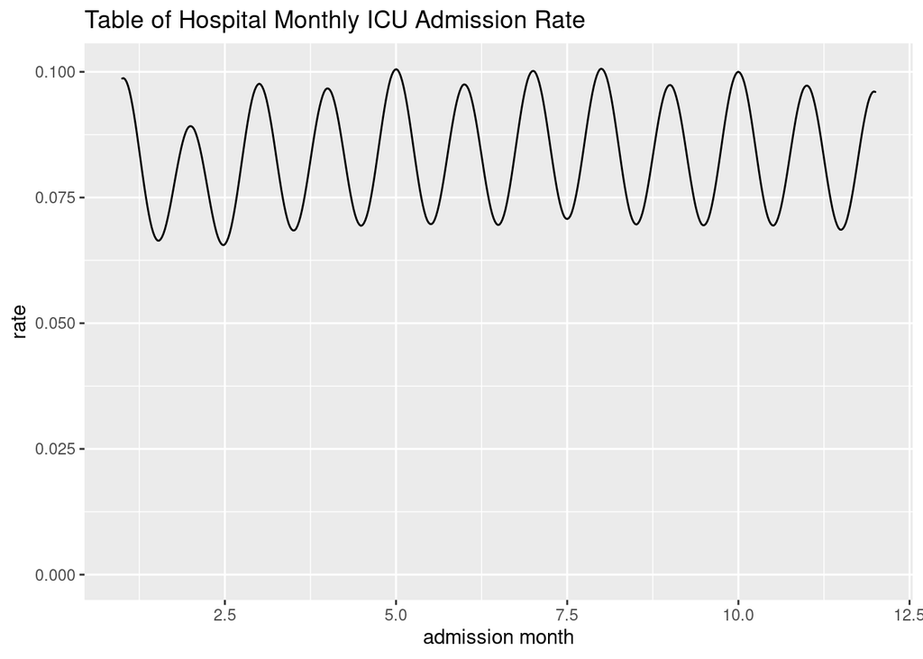

```r
admmontb=
  ggplot(admission_tble) +
  geom_density(aes(month(admittime))) +
  labs(x = "admission month", y = "rate",
       title = "Table of Hospital Monthly ICU Admission Rate")
admmontb
```

- admission month day

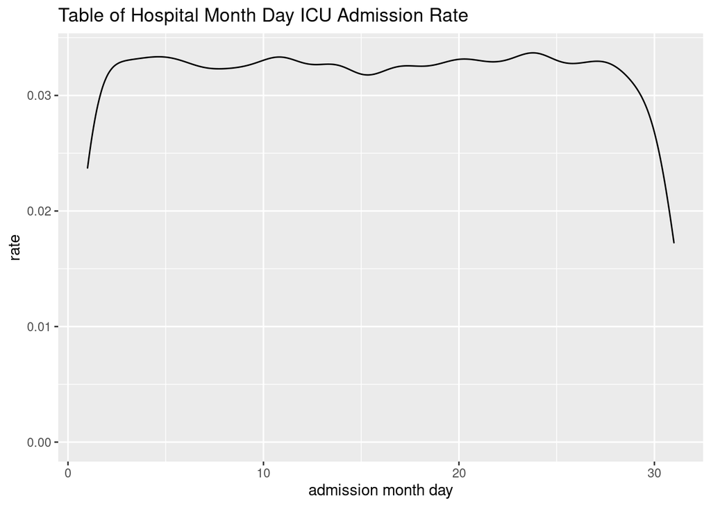

```r
admmonthdaytb=
  ggplot(admission_tble) +
  geom_density(aes(mday(admittime))) +
  labs(x = "admission month day", y = "rate",
       title = "Table of Hospital Month Day ICU Admission Rate")
admmonthdaytb
```

- admission week day

```r
admweekdaytb=
  ggplot(admission_tble) +
  geom_bar(stat="count") + aes(weekdays(admittime))
  labs(x = "admission week day", y = "count",
       title = "Table of Hospital Week day ICU Admission Count")
```

```
## $x
## [1] "admission week day"
##
## $y
## [1] "count"
##
## $title
## [1] "Table of Hospital Week day ICU Admission Count"
##
## attr(,"class")
## [1] "labels"
```

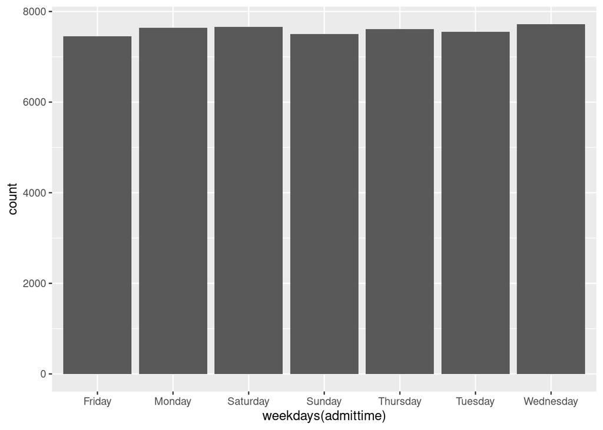

```r
admweekdaytb
```

- admission hour (anything unusual?)

```r
hourtb=
  ggplot(admission_tble) +
  geom_bar(stat="count") + aes(hour(admittime))
  labs(x = "admission hour", y = "count",
       title = "Table of Hourly Hospital ICU Admission Count")
```

```
## $x
## [1] "admission hour"
##
## $y
## [1] "count"
##
## $title
## [1] "Table of Hourly Hospital ICU Admission Count"
##
## attr(,"class")
## [1] "labels"
```

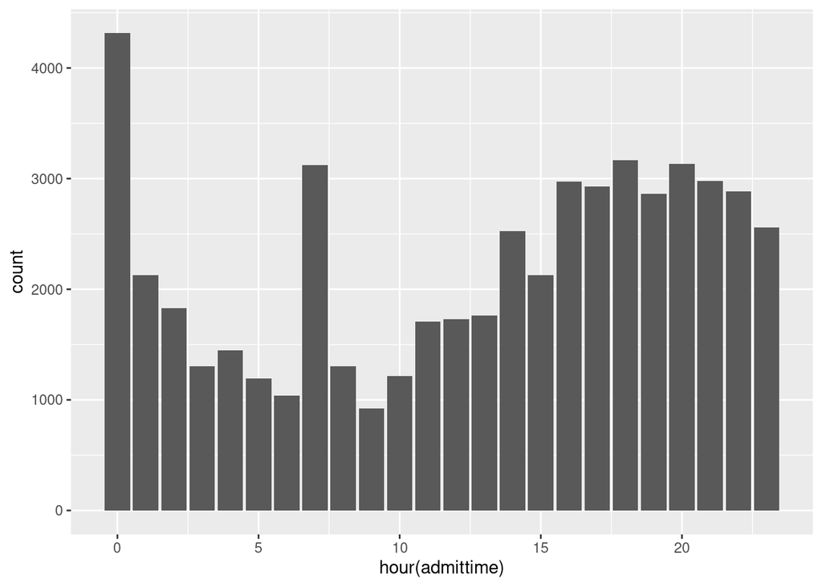

```r
hourtb
```

## Q4. `patients` data

Patient information is available in `patients.csv.gz`. See https://mimic.mit.edu/docs/iv/modules/core/patients/ for details of each field in this file. The first 10 lines are

```r
system(
  str_c(
    "zcat < ",
    shQuote(str_c(mimic_path, "/core/patients.csv.gz")),
    " | head"
    ),
  intern = TRUE
)
```

```
##  [1] "subject_id,gender,anchor_age,anchor_year,anchor_year_group,dod"
##  [2] "10000048,F,23,2126,2008 - 2010,"
##  [3] "10002723,F,0,2128,2017 - 2019,"
##  [4] "10003939,M,0,2184,2008 - 2010,"
##  [5] "10004222,M,0,2161,2014 - 2016,"
##  [6] "10005325,F,0,2154,2011 - 2013,"
##  [7] "10007338,F,0,2153,2017 - 2019,"
##  [8] "10008101,M,0,2142,2008 - 2010,"
##  [9] "10009872,F,0,2168,2014 - 2016,"
## [10] "10011333,F,0,2132,2014 - 2016,"
```

1. Import `patients.csv.gz` (https://mimic.mit.edu/docs/iv/modules/core/patients/) as a tibble `patients_tble` and only keep the patients who have a match in `icustays_tble` (according to `subject_id`).

```r
patients_tble =
  read_csv(str_c(mimic_path, "/core/patients.csv.gz"))
patients_tble =
  semi_join(patients_tble, icustays_tble,
      by = c("subject_id"))
```

2. Summarize variables `gender` and `anchor_age`, and explain any patterns you see.

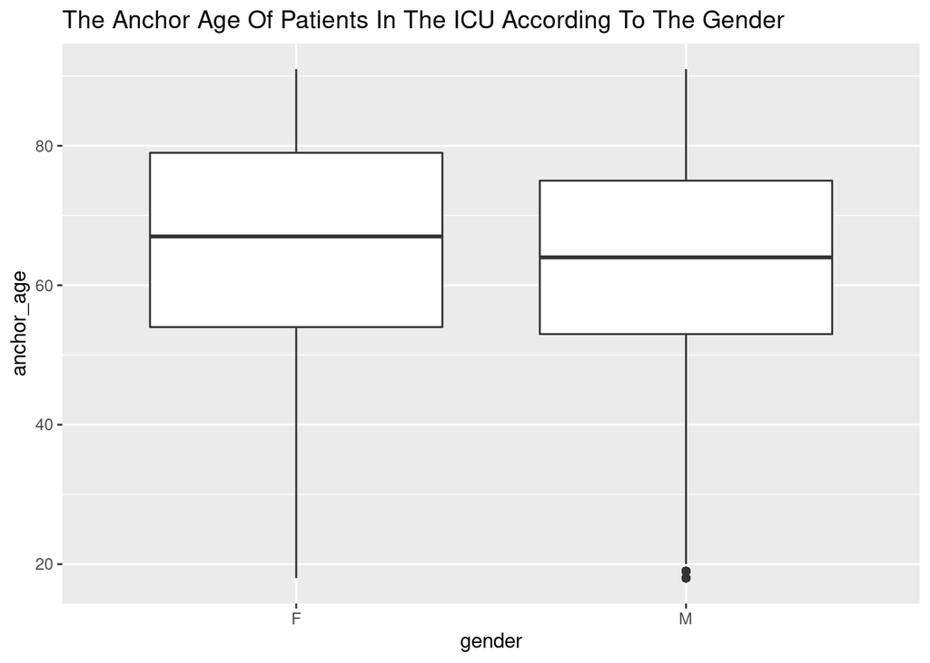

```r
genderplot=
  ggplot(patients_tble) +
  geom_boxplot(aes(x=gender,y=anchor_age)) +
  labs(x = "gender", y = "anchor_age",
       title = "The Anchor Age Of Patients In The ICU According To The Gender")
genderplot
```

The pattern is that male tend to have a slightly lower average anchor age than female patients in the ICU. The ranges of the anchor age for both gender are very similar.

## Q5. Lab results

`labevents.csv.gz` (https://mimic.mit.edu/docs/iv/modules/hosp/labevents/) contains all laboratory measurements for patients. The first 10 lines are

```r
system(
  str_c(
    "zcat < ",
    shQuote(str_c(mimic_path, "/hosp/labevents.csv.gz")),
    " | head"
    ),
  intern = TRUE
)
```

```
##  [1] "labevent_id,subject_id,hadm_id,specimen_id,itemid,charttime,storetime,value,valuenum,valueuom,ref_range_lower,ref_range_upper,flag,priority,comments"
##  [2] "670,10000048,,6448755,51484,2126-11-22 19:20:00,2126-11-22 20:07:00,150,150,mg/dL,,,,STAT,"
##  [3] "673,10000048,,6448755,51491,2126-11-22 19:20:00,2126-11-22 20:07:00,6.5,6.5,units,5,8,,STAT,"
##  [4] "675,10000048,,6448755,51498,2126-11-22 19:20:00,2126-11-22 20:07:00,1.029,1.029, ,1.001,1.035,,STAT,"
##  [5] "683,10000048,,82729055,50861,2126-11-22 20:45:00,2126-11-23 00:55:00,39,39,IU/L,0,40,,STAT,"
##  [6] "684,10000048,,82729055,50862,2126-11-22 20:45:00,2126-11-23 00:55:00,4.7,4.7,g/dL,3.4,4.8,,STAT,"
##  [7] "685,10000048,,82729055,50863,2126-11-22 20:45:00,2126-11-23 00:55:00,45,45,IU/L,39,117,,STAT,"
##  [8] "686,10000048,,82729055,50868,2126-11-22 20:45:00,2126-11-22 21:32:00,13,13,mEq/L,8,20,,STAT,"
##  [9] "687,10000048,,82729055,50878,2126-11-22 20:45:00,2126-11-23 00:55:00,28,28,IU/L,0,40,,STAT,"
## [10] "688,10000048,,82729055,50882,2126-11-22 20:45:00,2126-11-22 21:32:00,26,26,mEq/L,22,32,,STAT,"
```

`d_labitems.csv.gz` is the dictionary of lab measurements.

```r
system(
  str_c(
    "zcat < ",
    shQuote(str_c(mimic_path, "/hosp/d_labitems.csv.gz")),
    " | head"
    ),
  intern = TRUE
)
```

```
##  [1] "itemid,label,fluid,category,loinc_code"
##  [2] "51905, ,Other Body Fluid,Chemistry,"
##  [3] "51532,11-Deoxycorticosterone,Blood,Chemistry,"
##  [4] "51957,17-Hydroxycorticosteroids,Urine,Chemistry,"
##  [5] "51958,\"17-Ketosteroids, Urine\",Urine,Chemistry,"
##  [6] "52068,24 Hr,Blood,Hematology,"
##  [7] "51066,24 hr Calcium,Urine,Chemistry,"
##  [8] "51067,24 hr Creatinine,Urine,Chemistry,"
##  [9] "51068,24 hr Protein,Urine,Chemistry,"
## [10] "50853,25-OH Vitamin D,Blood,Chemistry,"
```

1. Find how many rows are in `labevents.csv.gz`.

```r
labevents=
  read_csv ("/mnt/mimiciv/1.0/hosp/labevents_filtered_itemid.csv.gz")
count(labevents)
```

```
## # A tibble: 1 × 1
##          n
##      <int>
## 1 30198826
```

2. We are interested in the lab measurements of creatinine (50912), potassium (50971), sodium (50983), chloride (50902), bicarbonate (50882), hematocrit (51221), white blood cell count (51301), glucose (50931), magnesium (50960), and calcium (50893). Retrieve a subset of `labevents.csv.gz` only containing these items for the patients in `icustays_tble` as a tibble `labevents_tble`.

   Hint: `labevents.csv.gz` is a data file too big to be read in by the `read_csv` function in its default setting. Utilize the `col_select` and `lazy` options in the `read_csv` function to reduce the memory burden.

```r
labevents_tble =
  read_csv("/mnt/mimiciv/1.0/hosp/labevents_filtered_itemid.csv.gz",
          col_select = c("subject_id", "itemid"), lazy = TRUE) %>%
  filter(itemid == "50912" & itemid == "50971"
         & itemid == "50983" & itemid == "50902" & itemid == "50882"
         & itemid == "51221" & itemid == "51301" & itemid == "50931"
         & itemid == "50960" & itemid == "50893") %>%
  semi_join(icustays_tble, by = "subject_id")
```

3. Further restrict `labevents_tble` to the first lab measurement during the ICU stay.

```r
d_labitems_tble =
  read_csv(str_c(mimic_path, "/hosp/d_labitems.csv.gz"))
d_labitems_tble
```

```
## # A tibble: 1,630 × 5
##    itemid label                     fluid            category   loinc_code
##     <dbl> <chr>                     <chr>            <chr>      <chr>
##  1  51905 <NA>                      Other Body Fluid Chemistry  <NA>
##  2  51532 11-Deoxycorticosterone    Blood            Chemistry  <NA>
##  3  51957 17-Hydroxycorticosteroids Urine            Chemistry  <NA>
##  4  51958 17-Ketosteroids, Urine    Urine            Chemistry  <NA>
##  5  52068 24 Hr                     Blood            Hematology <NA>
##  6  51066 24 hr Calcium             Urine            Chemistry  <NA>
##  7  51067 24 hr Creatinine          Urine            Chemistry  <NA>
##  8  51068 24 hr Protein             Urine            Chemistry  <NA>
##  9  50853 25-OH Vitamin D           Blood            Chemistry  <NA>
## 10  51533 3t                        Blood            Chemistry  <NA>
## # … with 1,620 more rows
```

```r
new_icutable =
  icustays_tble %>%
  select(subject_id, intime)
```

```r
labevents_tble =
  read_csv("/mnt/mimiciv/1.0/hosp/labevents_filtered_itemid.csv.gz") %>%
  left_join(new_icutable, by = c("subject_id")) %>%
  drop_na() %>%
  filter(charttime > intime) %>%
  group_by(subject_id, itemid) %>%
  arrange(charttime, .by_group = TRUE) %>%
  slice(n=1) %>%
  select(-intime , -charttime) %>%
  ungroup() %>%
  left_join(select(d_labitems_tble, itemid, label),
            by = c("itemid" ))%>%
  select(-itemid) %>%
  pivot_wider(names_from =label, values_from = valuenum) %>%
  print(width = Inf)
```

```
## # A tibble: 52,446 × 11
##    subject_id Bicarbonate `Calcium, Total` Chloride Creatinine Glucose Magnesium
##         <dbl>       <dbl>            <dbl>    <dbl>      <dbl>   <dbl>     <dbl>
##  1   10000032          21              9.3      102        0.5     115       2.3
##  2   10000980          23              9.2      103        2.2     144       2
##  3   10001217          24              8.5      106        0.5     113       1.8
##  4   10001725          24              9.1      106        0.8     146       1.5
##  5   10001884          33              9.8       96        1.1     148       2.2
##  6   10002013          23              8.2      109        1.1      98       2.1
##  7   10002155          22              8        106        2.5     106       2.2
##  8   10002223          26              8.7      102        0.8      88       2
##  9   10002348          23              9.4      107        0.8     127       1.6
## 10   10002428          20              7.4       98        0.8      99       1.4
##    Potassium Sodium Hematocrit `White Blood Cells`
##        <dbl>  <dbl>      <dbl>               <dbl>
##  1       4.7    132       34.8                 4.1
##  2       4.2    139       30.8                 5.4
##  3       4.3    139       37.5                 8.4
##  4       3.9    140       39.1                17
##  5       4      136       36                  18.4
##  6       4      140       28.6                18.2
##  7       4.6    136       19.3                 9.5
##  8       3.9    138       32.5                10.1
##  9       4.8    142       39.3                 4.3
## 10       3.9    129       28.7                22.4
## # … with 52,436 more rows
```

```r
labevents_tble
```

```
## # A tibble: 52,446 × 11
##    subject_id Bicarbonate `Calcium, Total` Chloride Creatinine Glucose Magnesium
##         <dbl>       <dbl>            <dbl>    <dbl>      <dbl>   <dbl>     <dbl>
##  1   10000032          21              9.3      102        0.5     115       2.3
##  2   10000980          23              9.2      103        2.2     144       2
##  3   10001217          24              8.5      106        0.5     113       1.8
##  4   10001725          24              9.1      106        0.8     146       1.5
##  5   10001884          33              9.8       96        1.1     148       2.2
##  6   10002013          23              8.2      109        1.1      98       2.1
##  7   10002155          22              8        106        2.5     106       2.2
##  8   10002223          26              8.7      102        0.8      88       2
##  9   10002348          23              9.4      107        0.8     127       1.6
## 10   10002428          20              7.4       98        0.8      99       1.4
## # … with 52,436 more rows, and 4 more variables: Potassium <dbl>, Sodium <dbl>,
## #   Hematocrit <dbl>, White Blood Cells <dbl>
```

4. Summarize the lab measurements by appropriate numerics and graphics.

```r
labevents_summary =
  labevents_tble %>%
  rename("Calcium" = "Calcium, Total") %>%
  select(-subject_id) %>%
  summary() %>%
  knitr::kable()

labevents_summary
```

|  | Bicarbonate | Calcium | Chloride | Creatinine | Glucose | Magnesium | Potassium | Sodium | Hematocrit | White Blood Cells |
| --- | --- | --- | --- | --- | --- | --- | --- | --- | --- | --- |
|  | Min. : 2.00 | Min. : 0.000 | Min. : 57.0 | Min. : 0.000 | Min. : 7.0 | Min. : 0.000 | Min. : 0.800 | Min. : 92.0 | Min. : 4.30 | Min. : 0.00 |
|  | 1st Qu.:21.00 | 1st Qu.: 7.900 | 1st Qu.:101.0 | 1st Qu.: 0.700 | 1st Qu.: 102.0 | 1st Qu.: 1.700 | 1st Qu.: 3.700 | 1st Qu.:136.0 | 1st Qu.:27.80 | 1st Qu.: 7.50 |
|  | Median :23.00 | Median : 8.400 | Median :105.0 | Median : 0.900 | Median : 123.0 | Median : 2.000 | Median : 4.100 | Median :139.0 | Median :32.40 | Median : 10.50 |
|  | Mean :23.06 | Mean : 8.371 | Mean :104.4 | Mean : 1.316 | Mean : 140.5 | Mean : 2.006 | Mean : 4.179 | Mean :138.5 | Mean :32.56 | Mean : 12.02 |
|  | 3rd Qu.:26.00 | 3rd Qu.: 8.900 | 3rd Qu.:108.0 | 3rd Qu.: 1.300 | 3rd Qu.: 155.0 | 3rd Qu.: 2.200 | 3rd Qu.: 4.500 | 3rd Qu.:141.0 | 3rd Qu.:37.10 | 3rd Qu.: 14.40 |
|  | Max. :50.00 | Max. :43.000 | Max. :154.0 | Max. :36.900 | Max. :2440.0 | Max. :47.000 | Max. :10.000 | Max. :185.0 | Max. :68.60 | Max. :572.50 |
|  | NA’s :108 | NA’s :1297 | NA’s :96 | NA’s :84 | NA’s :117 | NA’s :281 | NA’s :86 | NA’s :88 | NA’s :105 | NA’s :131 |

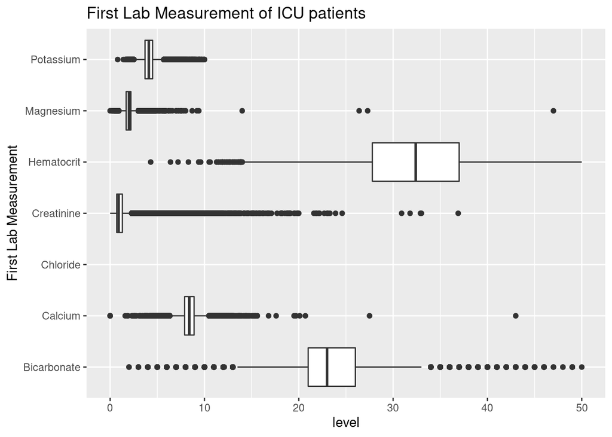

```r
flabplot=
  labevents_tble %>%
  rename("Calcium" = "Calcium, Total") %>%
  pivot_longer("Bicarbonate" : "White Blood Cells",
               names_to = "item_id",
               values_to = "values") %>%
  select(-subject_id) %>%
  group_by(item_id) %>%
  filter(item_id == "Bicarbonate"
         | item_id == "Calcium"
         | item_id == "Chloride"
         | item_id == "Creatinine"
         | item_id == "Magnesium"
         | item_id == "Potassium"
         | item_id == "Hematocrit"
         ) %>%
  ggplot(aes(x = item_id, y = values)) +
  geom_boxplot() +
  coord_flip() +
  ylim(0, 50) +
  labs(x = "First Lab Measurement",
       y = "level",
       title = "First Lab Measurement of ICU patients")

flabplot
```

## Q6. Vitals from charted events

`chartevents.csv.gz` (https://mimic.mit.edu/docs/iv/modules/icu/chartevents/) contains all the charted data available for a patient. During their ICU stay, the primary repository of a patient’s information is their electronic chart. The `itemid` variable indicates a single measurement type in the database. The `value` variable is the value measured for `itemid`. The first 10 lines of `chartevents.csv.gz` are

```r
system(
  str_c(
    "zcat < ",
    shQuote(str_c(mimic_path, "/icu/chartevents.csv.gz")),
    " | head"),
  intern = TRUE
)
```

```
##  [1] "subject_id,hadm_id,stay_id,charttime,storetime,itemid,value,valuenum,valueuom,warning"
##  [2] "10003700,28623837,30600691,2165-04-24 05:10:00,2165-04-24 05:11:00,228236,0,0,,0"
##  [3] "10003700,28623837,30600691,2165-04-24 05:12:00,2165-04-24 05:14:00,225067,0,0,,0"
##  [4] "10003700,28623837,30600691,2165-04-24 05:12:00,2165-04-24 05:14:00,225070,1,1,,0"
##  [5] "10003700,28623837,30600691,2165-04-24 05:12:00,2165-04-24 05:14:00,225076,1,1,,0"
##  [6] "10003700,28623837,30600691,2165-04-24 05:12:00,2165-04-24 05:14:00,225078,1,1,,0"
##  [7] "10003700,28623837,30600691,2165-04-24 05:12:00,2165-04-24 05:14:00,225086,1,1,,0"
##  [8] "10003700,28623837,30600691,2165-04-24 05:12:00,2165-04-24 05:14:00,225091,1,1,,0"
##  [9] "10003700,28623837,30600691,2165-04-24 05:12:00,2165-04-24 05:14:00,225103,1,1,,0"
## [10] "10003700,28623837,30600691,2165-04-24 05:12:00,2165-04-24 05:14:00,225106,1,1,,0"
```

`d_items.csv.gz` (https://mimic.mit.edu/docs/iv/modules/icu/d_items/) is the dictionary for the `itemid` in `chartevents.csv.gz`.

```r
system(
  str_c(
    "zcat < ",
    shQuote(str_c(mimic_path, "/icu/d_items.csv.gz")),
    " | head"),
  intern = TRUE
)
```

```
##  [1] "itemid,label,abbreviation,linksto,category,unitname,param_type,lownormalvalue,highnormalvalue"
##  [2] "220003,ICU Admission date,ICU Admission date,datetimeevents,ADT,,Date and time,,"
##  [3] "220045,Heart Rate,HR,chartevents,Routine Vital Signs,bpm,Numeric,,"
##  [4] "220046,Heart rate Alarm - High,HR Alarm - High,chartevents,Alarms,bpm,Numeric,,"
##  [5] "220047,Heart Rate Alarm - Low,HR Alarm - Low,chartevents,Alarms,bpm,Numeric,,"
##  [6] "220048,Heart Rhythm,Heart Rhythm,chartevents,Routine Vital Signs,,Text,,"
##  [7] "220050,Arterial Blood Pressure systolic,ABPs,chartevents,Routine Vital Signs,mmHg,Numeric,90,140"
##  [8] "220051,Arterial Blood Pressure diastolic,ABPd,chartevents,Routine Vital Signs,mmHg,Numeric,60,90"
##  [9] "220052,Arterial Blood Pressure mean,ABPm,chartevents,Routine Vital Signs,mmHg,Numeric,,"
## [10] "220056,Arterial Blood Pressure Alarm - Low,ABP Alarm - Low,chartevents,Alarms,mmHg,Numeric,,"
```

1. We are interested in the vitals for ICU patients: heart rate (220045), mean non-invasive blood pressure (220181), systolic non-invasive blood pressure (220179), body temperature in Fahrenheit (223761), and respiratory rate (220210). Retrieve a subset of `chartevents.csv.gz` only containing these items for the patients in `icustays_tble` as a tibble `chartevents_tble`.

```r
chartevents_tble =
  read_csv("/mnt/mimiciv/1.0/icu/chartevents_filtered_itemid.csv.gz",
          col_select = c("subject_id", "itemid"), lazy = TRUE) %>%
  filter(itemid == "220045"
         & itemid == "220181"
         & itemid == "220179"
         & itemid == "223761"
         & itemid == "220210") %>%
  semi_join(icustays_tble, by = c ("subject_id"))
```

2. Further restrict `chartevents_tble` to the first vital measurement during the ICU stay.

```r
read_csv("/mnt/mimiciv/1.0/icu/chartevents_filtered_itemid.csv.gz")
```

```
## # A tibble: 23,679,058 × 6
##    subject_id  hadm_id  stay_id charttime           itemid valuenum
##         <dbl>    <dbl>    <dbl> <dttm>               <dbl>    <dbl>
##  1   10003700 28623837 30600691 2165-04-24 05:28:00 220179    152
##  2   10003700 28623837 30600691 2165-04-24 05:28:00 220181    110
##  3   10003700 28623837 30600691 2165-04-24 05:30:00 220045     65
##  4   10003700 28623837 30600691 2165-04-24 05:30:00 220210     14
##  5   10003700 28623837 30600691 2165-04-24 05:38:00 223761     97.6
##  6   10003700 28623837 30600691 2165-04-24 06:00:00 220045     56
##  7   10003700 28623837 30600691 2165-04-24 06:00:00 220179    126
##  8   10003700 28623837 30600691 2165-04-24 06:00:00 220181     88
##  9   10003700 28623837 30600691 2165-04-24 06:00:00 220210     14
## 10   10003700 28623837 30600691 2165-04-24 06:09:00 220045     55
## # … with 23,679,048 more rows
```

```r
d1_labitems_tble =
  read_csv(str_c(mimic_path, "/icu/d_items.csv.gz"))
d1_labitems_tble
```

```
## # A tibble: 3,861 × 9
##    itemid label abbreviation linksto category unitname param_type lownormalvalue
##     <dbl> <chr> <chr>        <chr>   <chr>    <chr>    <chr>               <dbl>
##  1 220003 ICU … ICU Admissi… dateti… ADT      <NA>     Date and …             NA
##  2 220045 Hear… HR           charte… Routine… bpm      Numeric                NA
##  3 220046 Hear… HR Alarm - … charte… Alarms   bpm      Numeric                NA
##  4 220047 Hear… HR Alarm - … charte… Alarms   bpm      Numeric                NA
##  5 220048 Hear… Heart Rhythm charte… Routine… <NA>     Text                   NA
##  6 220050 Arte… ABPs         charte… Routine… mmHg     Numeric                90
##  7 220051 Arte… ABPd         charte… Routine… mmHg     Numeric                60
##  8 220052 Arte… ABPm         charte… Routine… mmHg     Numeric                NA
##  9 220056 Arte… ABP Alarm -… charte… Alarms   mmHg     Numeric                NA
## 10 220058 Arte… ABP Alarm -… charte… Alarms   mmHg     Numeric                NA
## # … with 3,851 more rows, and 1 more variable: highnormalvalue <dbl>
```

```r
new_icutable =
  icustays_tble %>%
  select(subject_id, intime)
```

```r
chartevents_tble =
  read_csv("/mnt/mimiciv/1.0/icu/chartevents_filtered_itemid.csv.gz") %>%
  left_join(new_icutable, by = c("subject_id")) %>%
  filter(charttime > intime) %>%
  group_by(subject_id, itemid) %>%
  arrange(charttime, .by_group = TRUE) %>%
  slice(1) %>%
  select(-charttime, -intime) %>%
  ungroup() %>%
  left_join(select(d1_labitems_tble, itemid, label),
            by = c("itemid" ))%>%
  select(-itemid) %>%
  pivot_wider(names_from = label, values_from = valuenum) %>%
  print(width = Inf)
```

```
## # A tibble: 53,288 × 8
##    subject_id  hadm_id  stay_id `Heart Rate`
##         <dbl>    <dbl>    <dbl>        <dbl>
##  1   10000032 29079034 39553978           91
##  2   10000980 26913865 39765666           77
##  3   10001217 27703517 34592300           96
##  4   10001725 25563031 31205490           55
##  5   10001884 26184834 37510196           38
##  6   10002013 23581541 39060235           80
##  7   10002155 28994087 31090461           94
##  8   10002223 22494570 39638202          100
##  9   10002348 22725460 32610785           72
## 10   10002428 28662225 33987268          124
##    `Non Invasive Blood Pressure systolic` `Non Invasive Blood Pressure mean`
##                                     <dbl>                              <dbl>
```

[output cut: 23 more lines]

3. Summarize these vital measurements by appropriate numerics and graphics.

```r
chartevents_summary =
  chartevents_tble %>%
  select(-subject_id, -hadm_id, -stay_id) %>%
  summary() %>%
  knitr::kable()
chartevents_summary
```

|  | Heart Rate | Non Invasive Blood Pressure systolic | Non Invasive Blood Pressure mean | Respiratory Rate | Temperature Fahrenheit |
| --- | --- | --- | --- | --- | --- |
|  | Min. : 0.00 | Min. : 0.0 | Min. : 0.00 | Min. : 0.00 | Min. : 0.00 |
|  | 1st Qu.: 74.00 | 1st Qu.: 106.0 | 1st Qu.: 70.00 | 1st Qu.: 15.00 | 1st Qu.: 97.60 |
|  | Median : 85.00 | Median : 121.0 | Median : 80.00 | Median : 18.00 | Median : 98.10 |
|  | Mean : 87.73 | Mean : 123.4 | Mean : 84.74 | Mean : 18.83 | Mean : 98.05 |
|  | 3rd Qu.:100.00 | 3rd Qu.: 139.0 | 3rd Qu.: 93.00 | 3rd Qu.: 22.00 | 3rd Qu.: 98.70 |
|  | Max. :941.00 | Max. :12262.0 | Max. :120130.00 | Max. :180.00 | Max. :105.80 |
|  | NA’s :139 | NA’s :734 | NA’s :751 | NA’s :182 | NA’s :1094 |

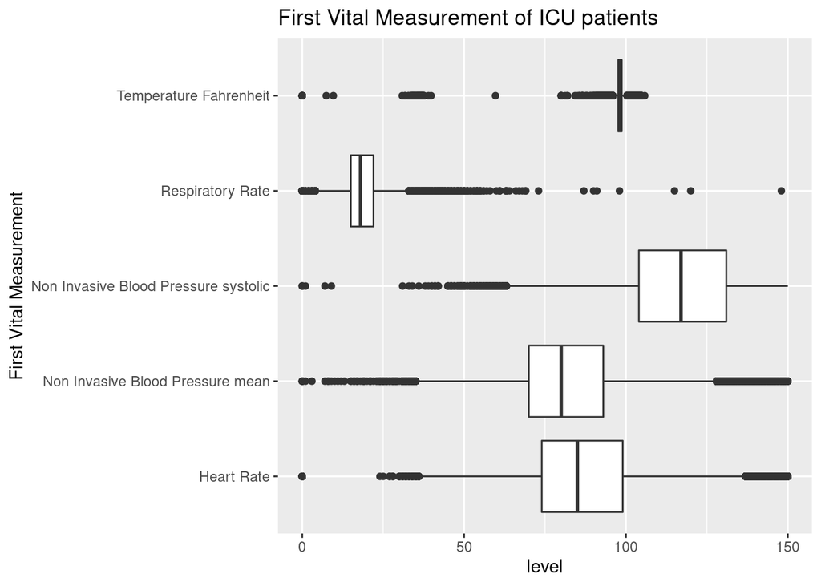

```r
vitalplot=
  chartevents_tble %>%
  pivot_longer("Heart Rate" : "Temperature Fahrenheit",
               names_to = "item_id",
               values_to = "values") %>%
  select(-subject_id) %>%
  group_by(item_id) %>%
  filter(item_id == "Heart Rate"
         | item_id == "Non Invasive Blood Pressure systolic"
         | item_id == "Non Invasive Blood Pressure mean"
         | item_id == "Respiratory Rate"
         | item_id == "Temperature Fahrenheit"
         ) %>%
  ggplot(aes(x = item_id, y = values)) +
  geom_boxplot() +
  coord_flip() +
  ylim(0, 150) +
  labs(x = "First Vital Measurement",
       y = "level",
       title = "First Vital Measurement of ICU patients")

vitalplot
```

## Q7. Putting things together

Let us create a tibble `mimic_icu_cohort` for all ICU stays, where rows are

- first ICU stay of each unique adult (age at admission > 18)

and columns contain at least following variables

- all variables in `icustays.csv.gz`
- all variables in `admission.csv.gz`
- all variables in `patients.csv.gz`
- first lab measurements during ICU stay
- first vital measurements during ICU stay
- an indicator variable `thirty_day_mort` whether the patient died within 30 days of hospital admission (30 day mortality)

```r
mimic_icu_cohort=
  icustays_tble %>%
  left_join(admission_tble,
            by = c("subject_id","hadm_id")) %>%
  left_join(patients_tble,
            by = c("subject_id")) %>%
  left_join(labevents_tble,
            by = c("subject_id")) %>%
  left_join(chartevents_tble,
            by = c("stay_id")) %>%
  mutate(age_hadm = anchor_age +
           year(admittime) - anchor_year) %>%
  filter((age_hadm) > 18) %>%
  mutate(hadm_death = ifelse(is.na(deathtime),
                             Inf, deathtime -admittime)) %>%
  mutate(thirty_day_mort =
           hadm_death <= 2592000) %>%
  print(width = Inf)
```

```
## # A tibble: 53,067 × 46
##    subject_id.x hadm_id.x  stay_id first_careunit
##           <dbl>     <dbl>    <dbl> <chr>
##  1     17867402  24528534 31793211 Trauma SICU (TSICU)
##  2     14435996  28960964 31983544 Trauma SICU (TSICU)
##  3     17609946  27385897 33183475 Trauma SICU (TSICU)
##  4     18966770  23483021 34131444 Trauma SICU (TSICU)
##  5     12776735  20817525 34547665 Neuro Stepdown
##  6     10215159  24283593 34569476 Trauma SICU (TSICU)
##  7     14489052  26516390 35056286 Trauma SICU (TSICU)
##  8     15914763  28906020 36909804 Trauma SICU (TSICU)
##  9     16256226  20013290 39289362 Neuro Stepdown
## 10     19194449  21641999 39387567 Coronary Care Unit (CCU)
##    last_careunit            intime              outtime               los
##    <chr>                    <dttm>              <dttm>              <dbl>
```

[output cut: 119 more lines]

## Q8. Exploratory data analysis (EDA)

Summarize following information using appropriate numerics or graphs.

- `thirty_day_mort` vs demographic variables (ethnicity, language, insurance, marital_status, gender, age at hospital admission)

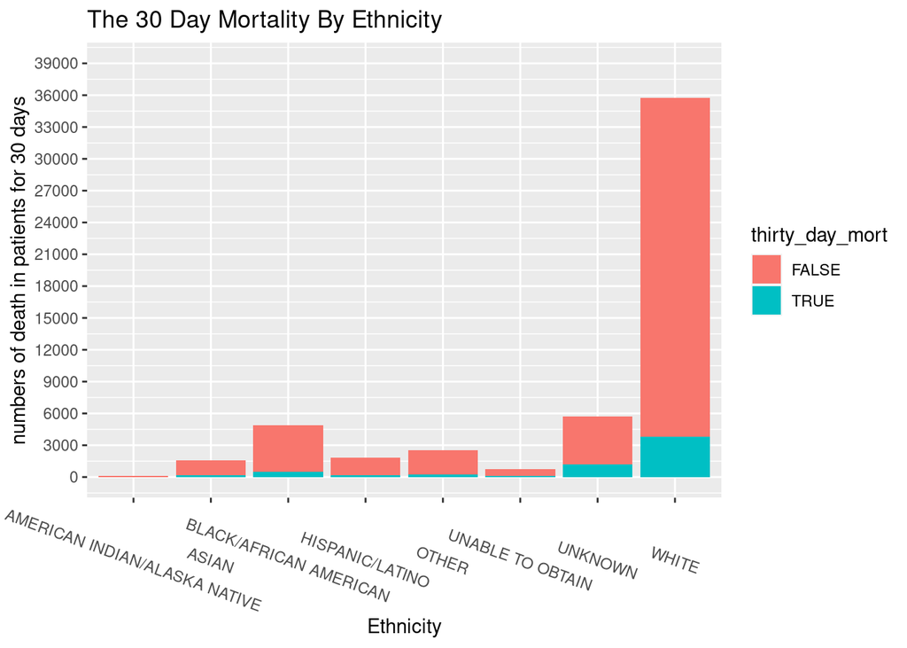

```r
demoplot=
  mimic_icu_cohort %>%
  select(ethnicity, thirty_day_mort) %>%
  group_by(ethnicity) %>%
  filter(ethnicity == "WHITE" | ethnicity == "BLACK/AFRICAN AMERICAN" |
           ethnicity == "ASIAN" |
           ethnicity == "UNKNOWN" | ethnicity == "OTHER"
          | ethnicity == "HISPANIC/LATINO"
         | ethnicity == "AMERICAN INDIAN/ALASKA NATIVE"
         | ethnicity == "UNABLE TO OBTAIN") %>%
  count(thirty_day_mort, name = 'number') %>%
  ggplot(aes(x = ethnicity, y= number, fill = thirty_day_mort)) +
  geom_bar(stat = "identity") +
  labs(x = "Ethnicity", y = "numbers of death in patients for 30 days",
       title = "The 30 Day Mortality By Ethnicity") +
  scale_y_continuous(
    breaks = c(0, 3000, 6000, 9000, 12000, 15000, 18000, 21000, 24000,
               27000, 30000, 33000, 36000, 39000),
    labels = c(0, 3000, 6000, 9000, 12000, 15000, 18000, 21000, 24000,
               27000, 30000, 33000, 36000, 39000),
               limits = c(0, 39000)) +
  theme(
      axis.text.x = element_text(angle = 340, vjust = 0.5, hjust = 0.5),
      legend.position = "right")

demoplot
```

- `thirty_day_mort` vs first lab measurements

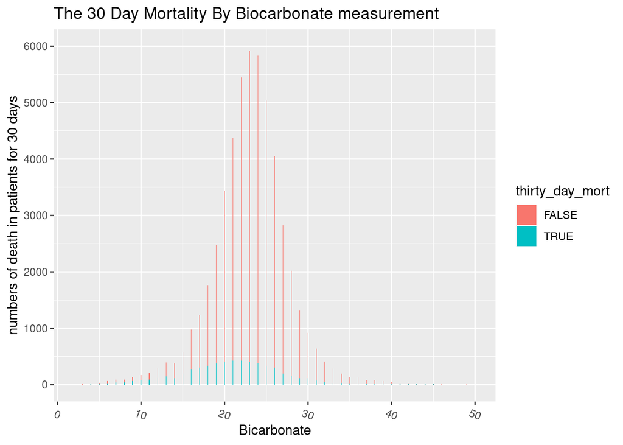

```r
#bicarbonate measurement
biplot=
  mimic_icu_cohort %>%
  select(Bicarbonate, thirty_day_mort) %>%
  group_by(Bicarbonate) %>%
  count(thirty_day_mort, name = 'number') %>%
  ggplot(aes(x = Bicarbonate, y= number, fill = thirty_day_mort)) +
  geom_bar(stat = "identity") +
  labs(x = "Bicarbonate", y = "numbers of death in patients for 30 days",
       title = "The 30 Day Mortality By Biocarbonate measurement") +
  scale_y_continuous(
    breaks = c(0, 1000, 2000, 3000, 4000, 5000, 6000),
    labels = c(0, 1000, 2000, 3000, 4000, 5000, 6000),
               limits = c(0, 6000)) +
  theme(
      axis.text.x = element_text(angle = 340, vjust = 0.5, hjust = 0.5),
      legend.position = "right")

biplot
```

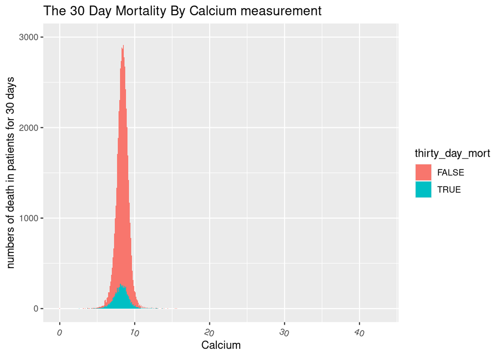

```r
#calcium
caplot=
  mimic_icu_cohort %>%
  rename("Calcium" = "Calcium, Total") %>%
  select(Calcium, thirty_day_mort) %>%
  group_by(Calcium) %>%
  count(thirty_day_mort, name = 'number') %>%
  ggplot(aes(x = Calcium, y= number, fill = thirty_day_mort)) +
  geom_bar(stat = "identity") +
  labs(x = "Calcium", y = "numbers of death in patients for 30 days",
       title = "The 30 Day Mortality By Calcium measurement") +
  scale_y_continuous(
    breaks = c(0, 1000, 2000, 3000),
    labels = c(0, 1000, 2000, 3000),
               limits = c(0, 3000)) +
  theme(
      axis.text.x = element_text(
        angle = 340, vjust = 0.5, hjust = 0.5),
      legend.position = "right")

caplot
```

- `thirty_day_mort` vs first vital measurements

[figure not shown]

```r
#heart rate
hrplot=
  mimic_icu_cohort %>%
  select(`Heart Rate`, thirty_day_mort) %>%
  group_by('Heart Rate') %>%
  count(thirty_day_mort, name = 'number') %>%
  ggplot(aes(x = "Heart Rate", y= number, fill = thirty_day_mort)) +
  geom_histogram(stat = "identity") +
  labs(x = "Rate", y = "numbers of death in patients for 30 days",
       title = "The 30 Day Mortality By Heart Rate measurement") +
  scale_y_continuous(
    breaks = c(0, 50, 100, 150, 200),
    labels = c(0, 50, 100, 150, 200),
               limits = c(0, 250)) +
  theme(
      axis.text.x = element_text(
        angle = 360, vjust = 0.5, hjust = 0.5),
      legend.position = "right")
hrplot
```

- `thirty_day_mort` vs first ICU unit

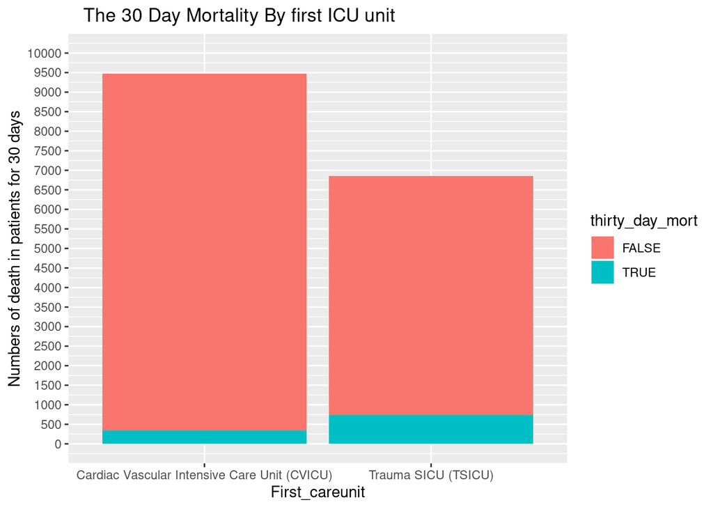

```r
Firstplot=
  mimic_icu_cohort %>%
  select(first_careunit, thirty_day_mort) %>%
  group_by(first_careunit) %>%
  filter(first_careunit == "Cardiac Vascular Intensive Care Unit (CVICU)"
         | first_careunit == "Trauma SICU (TSICU)" ) %>%
  count(thirty_day_mort, name = 'number') %>%
  ggplot(aes(x = first_careunit, y= number, fill = thirty_day_mort)) +
  geom_bar(stat = "identity") +
  labs(x = "First_careunit", y = "Numbers of death in patients for 30 days",
       title = "The 30 Day Mortality By first ICU unit") +
  scale_y_continuous(
    breaks = c(0,500, 1000, 1500, 2000, 2500, 3000, 3500, 4000,
               4500, 5000, 5500, 6000, 6500, 7000, 7500, 8000, 8500, 9000, 9500, 10000),
    labels = c(0,500, 1000, 1500, 2000, 2500, 3000, 3500, 4000,
               4500, 5000, 5500, 6000, 6500, 7000, 7500, 8000, 8500, 9000, 9500, 10000),
               limits = c(0, 10000)) +
  theme(plot.title = element_text(hjust = 0.08))

Firstplot
```